# Data Analysis for Data Science Class

Nattaya Mairittha

2017/11/22

## Propose

1. Exploratory data analysis of human activity data
2. Recognition of human activities using machine learning methods with mobile-sensor

## Dataset

**Human Activity Recognition Using Smartphones Data Set**

Human Activity Recognition database built from the recordings of 30 subjects performing activities of daily living (ADL) while carrying a waist-mounted smartphone with embedded inertial sensors.

**Data Set Information:**

| Items | Features | Items.1 | Features.1 | Items.2 | Features.2 |
| --- | --- | --- | --- | --- | --- |
| Data Set Characteristics: | Multivariate, Time-Series | Number of Instances: | 10299 | Area: | Computer |
| Attribute Characteristics: | N/A | Number of Attributes: | 561 | Date Donated: | 2012-12-10 |
| Associated Tasks: | Classification, Clustering | Missing Values? | N/A | Number of Web Hits: | 560332 |

**Source:** U.C.I. machine learning repository: http://archive.ics.uci.edu/ml/datasets/Human+Activity+Recognition+Using+Smartphones

## Exploratory data analysis:

Analyzing data sets to summarize their main characteristics with visual methods.

### Plotting max acceleration for the first subject

As shown in Fig. 1 and Fig. 2, we can see some activity classes varies. For example, lying and standing and sitting, there is not a lot of interesting things going on, whereas walking in, and walking up, and walking down, the maximum acceleration shows a lot of variability. so it might be a good predictor. So that may be a predictor of those kinds of activities.

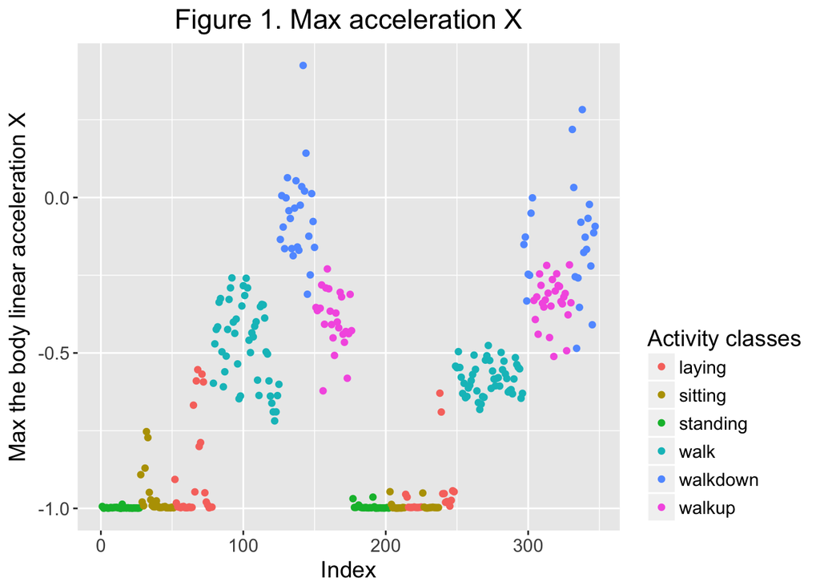

```r
# convert the activity variable into a factor variable.
samsungData <- transform(samsungData, activity = factor(activity))
# select only first subject
sub1 <- subset(samsungData, subject == 1)
par(mfrow=c(1,1))
# plot max x
qplot(seq_along(sub1$fBodyAcc.max...X), sub1$fBodyAcc.max...X, colour=sub1$activity) + labs(title ="Figure 1. Max acceleration X", x="Index",y="Max the body linear acceleration X", colour="Activity classes")  +
    theme(plot.title = element_text(hjust = 0.5),
          text=element_text(size=14,family="ArialMT"),
          legend.justification=c(1,0))
```

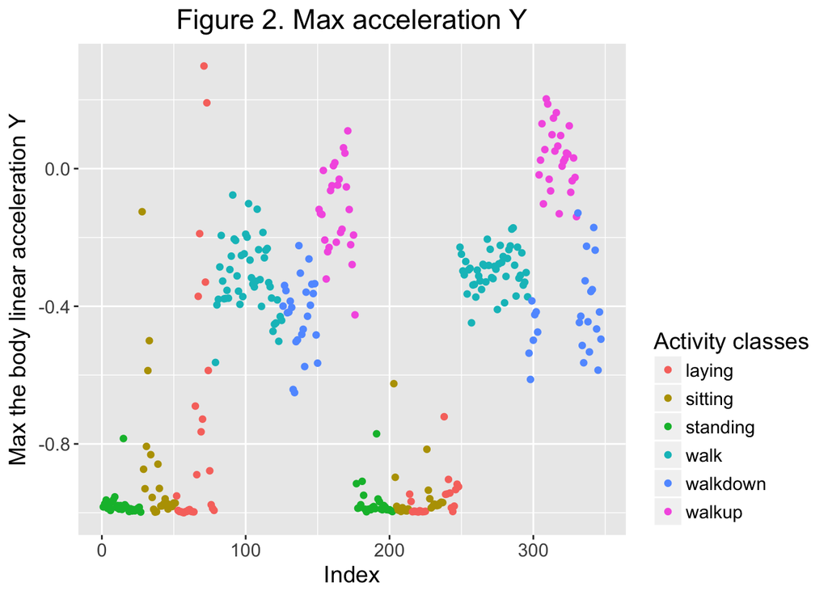

```r
# plot max y
qplot(seq_along(sub1$fBodyAcc.max...Y), sub1$fBodyAcc.max...Y, colour=sub1$activity) + labs(title="Figure 2. Max acceleration Y", x="Index",y="Max the body linear acceleration Y", colour="Activity classes")  +
  theme(plot.title = element_text(hjust = 0.5),
        text=element_text(size=14,family="ArialMT"),
        legend.justification=c(1,0))
```

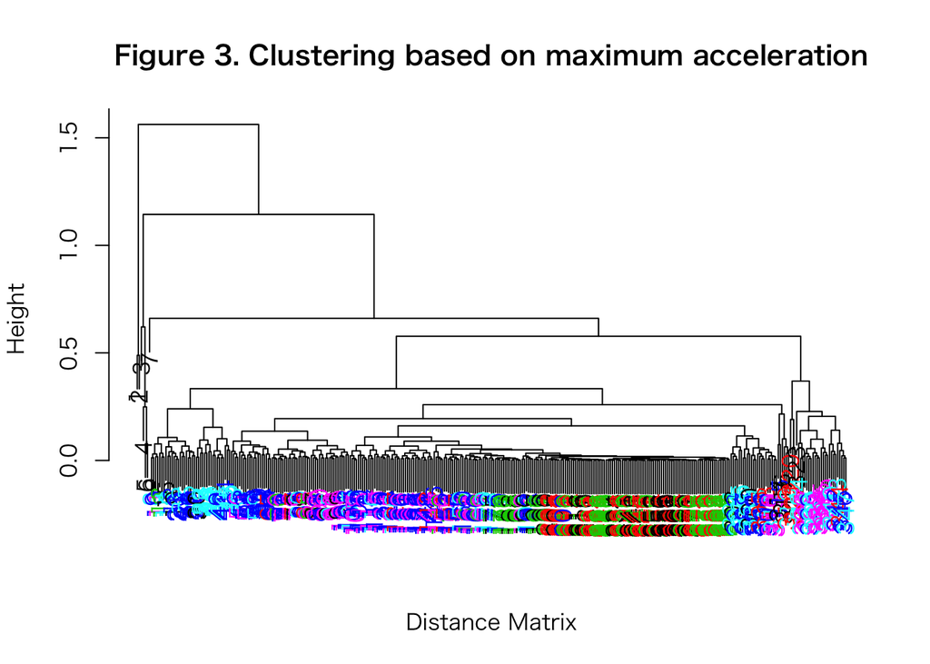

```r
# select first subject and select max acceleration x,y,z columns
numericActivity <- as.numeric(as.factor(samsungData$activity))[samsungData$subject==1]
distanceMatrix <- dist(samsungData[samsungData$subject==1,1:3])
hclustering <- hclust(distanceMatrix)
myplclust(hclustering,lab.col=numericActivity)
```

## Machine Learning for Human Activity Recognition

### Evaluating

1. Select feature set different and assign to columns. The details are presented in the table below.
2. Create a Validation Dataset: Separating data into training and testing sets. (In this case:50:50)
3. Feed the resulting features to the learning algorithm to build models
4. Use the model to generate predictions of the target answer for new data instances.
5. Evaluate the quality of the models on data that was held out from model building.

```r
samsungData$activity  <- as.factor(samsungData$activity)

# Select and assign feature columns because in this example case if select all, it takes longer times
names(samsungData)[1:12]
```

```
##  [1] "tBodyAcc.mean...X" "tBodyAcc.mean...Y" "tBodyAcc.mean...Z"
##  [4] "tBodyAcc.std...X"  "tBodyAcc.std...Y"  "tBodyAcc.std...Z"
##  [7] "tBodyAcc.mad...X"  "tBodyAcc.mad...Y"  "tBodyAcc.mad...Z"
## [10] "tBodyAcc.max...X"  "tBodyAcc.max...Y"  "tBodyAcc.max...Z"
```

```r
featcols = colnames(samsungData)[1:12]

# Split arrays or matrices into train and test subsets
subjects <- levels(factor(samsungData$subject))
train = samsungData[samsungData$subject %in% subjects[1:15],c(featcols,"activity")]
test = samsungData[samsungData$subject %in% subjects[16:30],c(featcols,"activity")]

# Machine Learning with KNN
pre = knn(train[,featcols],test[,featcols], train$activity)
result_knn <- do_eval(test$activity,pre)
```

```
## accuracy: 57.61 %, precision: 58.86 %, recall: 57.72 %, F-measure 58.29 %¥n          label
## pre        laying sitting standing walk walkdown walkup
##   laying      288      73       35    0        0      0
##   sitting     111     204      145    0        0      0
##   standing     43     130      251    0        0      0
##   walk          0       0        0  197       36    143
##   walkdown      0       0        0    5      228     44
##   walkup        0       0        0  160       44    149
```

```r
# Machine Learning with Naive Bayes
model = naiveBayes(activity~., train)
pre = predict(model, test)
result_bayes <- do_eval(test$activity,pre)
```

```
## accuracy: 48.43 %, precision: 55.77 %, recall: 49.75 %, F-measure 52.59 %¥n          label
## pre        laying sitting standing walk walkdown walkup
##   laying       48      10       12    0        0      0
##   sitting      14      12       28    0        0      0
##   standing    362     380      391    0        0      0
##   walk          3       0        0  322       74    202
##   walkdown      0       0        0    2      207      7
##   walkup       15       5        0   38       27    127
```

```r
# Machine Learning with Random forest
model = randomForest(activity~., train)
pre = predict(model, test)
result_random <- do_eval(test$activity,pre)
```

```
## accuracy: 63.87 %, precision: 63.44 %, recall: 63.1 %, F-measure 63.27 %¥n          label
## pre        laying sitting standing walk walkdown walkup
##   laying      364      78        9    1        0      0
##   sitting      54     198       84    1        0      0
##   standing     24     131      338    0        0      0
##   walk          0       0        0  176       47    138
##   walkdown      0       0        0    6      232     46
##   walkup        0       0        0  178       29    152
```

### Results

Following the evaluation approach discussed above, Fig. 4 shows the results for k-NN, NaiveBayes, and RandomForest as the underlying machine learning algorithm.

Averaging all activity classes, when we adopt k-NN as the underlying algorithm, **accuracy is 57.61 %.** When we adopt NaiveBayes as the underlying algorithm, **accuracy is 48.43 %.**, moreover, when we adopt RandomForest as the underlying algorithm, **accuracy is 63.87 %.**

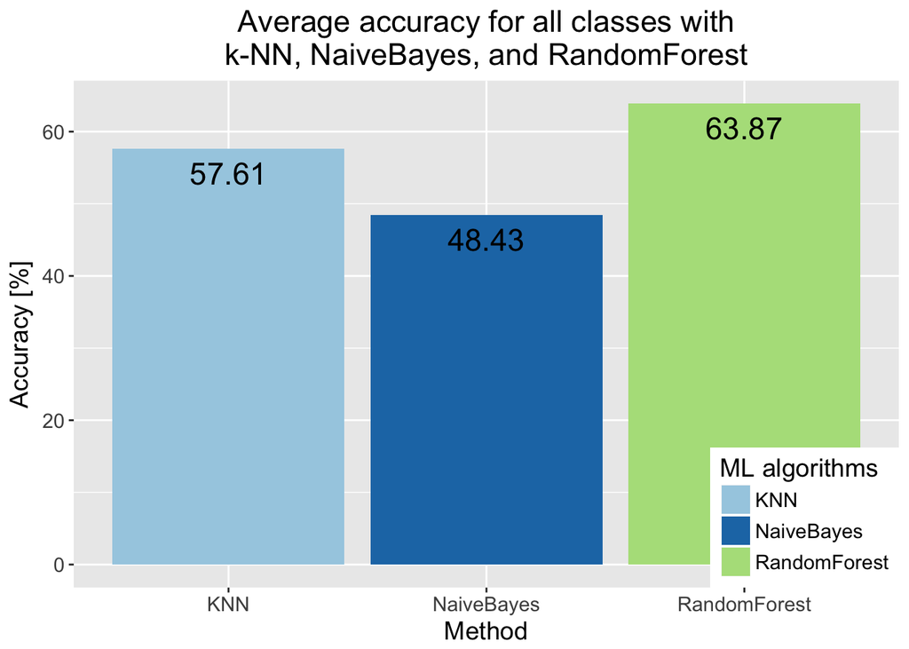